# QK Figs Box 6.8

Peake and Quinn (1993) investigated the relationship between the number of species of macroinvertebrates, the total abundance of macroinvertebrates, and area of clumps of mussels on a rocky shore in southern Australia. The variables of interest are clump area (dm<sup>2</sup>), number of species, and number of individuals.

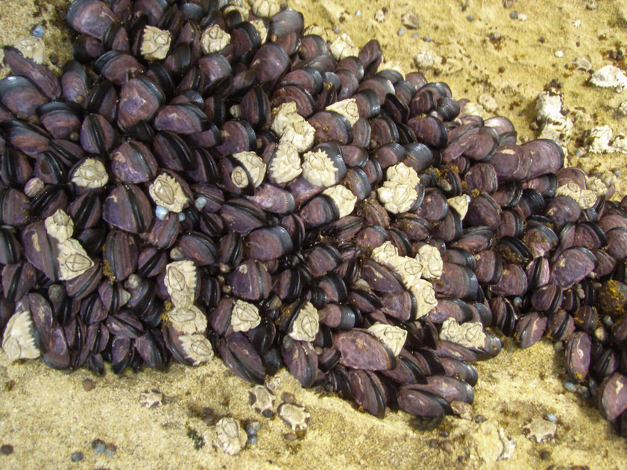

Clump of mussels, with barnacles and gastropods in the clump. Mick Keough

The data set was used in the first edition; get it here Peake, A. J. & Quinn, G. P. (1993). Temporal variation in species-area curves for invertebrates in clumps of an intertidal mussel. *Ecography*, 16, 269-77.

### Preliminaries

First, load the required packages (pwr)

```r
source("../R/libraries.R")   #the libraries script loads a common set of packages
library(pwr)
```

Load the data file and transform area, species and indiv

```r
peakquinn <- read_csv("../data/peakquinn.csv")
head(peakquinn)
```

| area | indiv | species |
| --- | --- | --- |
| 516 | 18 | 3 |
| 469 | 60 | 7 |
| 462 | 57 | 6 |
| 939 | 100 | 8 |
| 1357 | 48 | 10 |
| 1774 | 118 | 9 |

```r
peakquinn$larea<-log10(peakquinn$area)
peakquinn$lspecies<-log10(peakquinn$species)
peakquinn$lindiv<-log10(peakquinn$indiv)
```

### The relationship between species and area

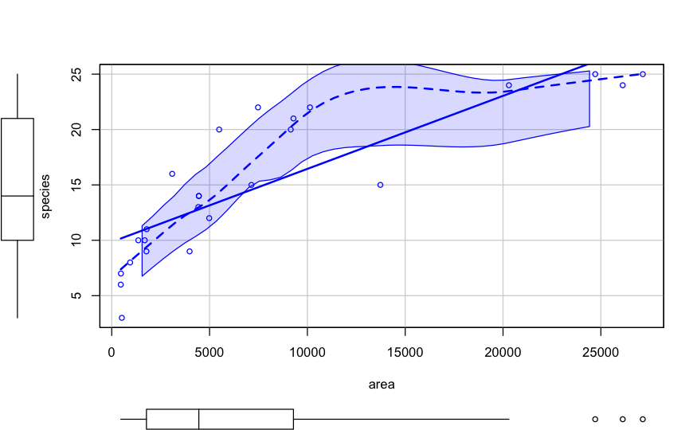

```r
scatterplot (species~area, data=peakquinn)
```

Problems with distributions, so use logged values

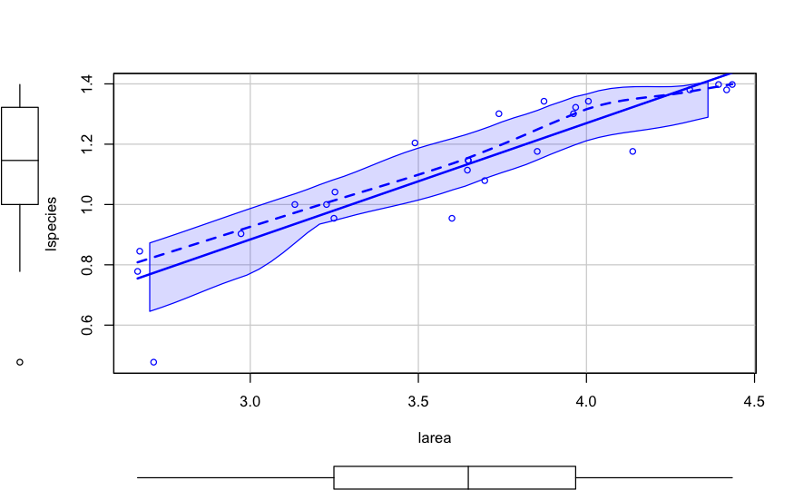

```r
scatterplot (lspecies~larea, data=peakquinn)
```

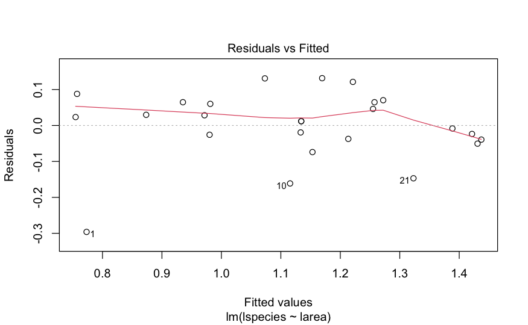

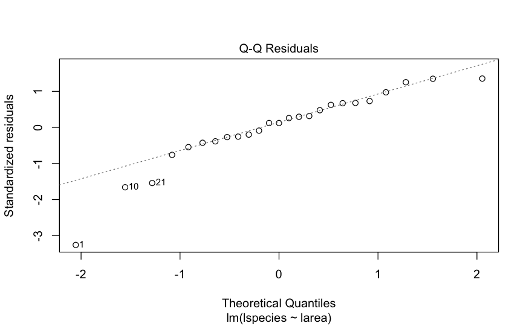

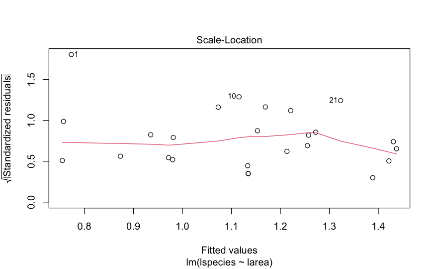

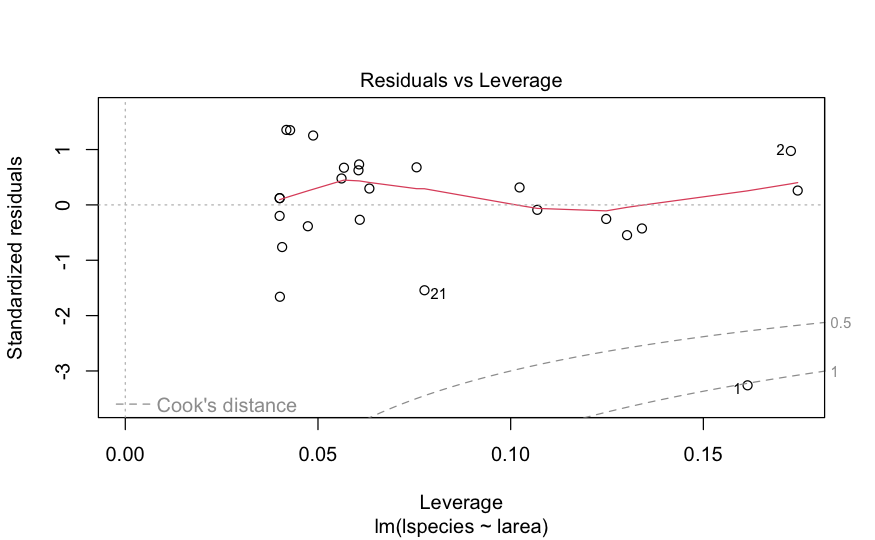

```r
pq.lm<-lm(lspecies~larea, data=peakquinn)
plot(pq.lm)
```

Residuals, etc., look much better now

Look at model fit

```r
options(digits=3)   # Tidy up output
augment(pq.lm)
```

| lspecies | larea | .fitted | .resid | .hat | .sigma | .cooksd | .std.resid |
| --- | --- | --- | --- | --- | --- | --- | --- |
| 0.477 | 2.71 | 0.773 | -0.29609 | 0.1615 | 0.0744 | 1.022785 | -3.259 |
| 0.845 | 2.67 | 0.757 | 0.08787 | 0.1727 | 0.0993 | 0.098990 | 0.974 |
| 0.778 | 2.66 | 0.755 | 0.02338 | 0.1745 | 0.1013 | 0.007107 | 0.259 |
| 0.903 | 2.97 | 0.873 | 0.02963 | 0.1023 | 0.1012 | 0.005662 | 0.315 |
| 1.000 | 3.13 | 0.935 | 0.06475 | 0.0756 | 0.1004 | 0.018839 | 0.679 |
| 0.954 | 3.25 | 0.980 | -0.02586 | 0.0608 | 0.1013 | 0.002343 | -0.269 |
| 1.000 | 3.23 | 0.972 | 0.02839 | 0.0633 | 0.1012 | 0.002956 | 0.296 |
| 1.041 | 3.25 | 0.981 | 0.06010 | 0.0605 | 0.1006 | 0.012581 | 0.625 |
| 1.204 | 3.49 | 1.073 | 0.13100 | 0.0428 | 0.0973 | 0.040688 | 1.350 |
| 0.954 | 3.60 | 1.116 | -0.16129 | 0.0401 | 0.0952 | 0.057543 | -1.659 |

[output cut: 15 more lines]

```r
glance(pq.lm)
```

| r.squared | adj.r.squared | sigma | statistic | p.value | df | logLik | AIC | BIC | deviance | df.residual | nobs |
| --- | --- | --- | --- | --- | --- | --- | --- | --- | --- | --- | --- |
| 0.819 | 0.812 | 0.0992 | 104 | 5.11e-10 | 1 | 23.3 | -40.7 | -37 | 0.226 | 23 | 25 |

```r
tidy(pq.lm, conf.int = TRUE)
```

| term | estimate | std.error | statistic | p.value | conf.low | conf.high |
| --- | --- | --- | --- | --- | --- | --- |
| (Intercept) | -0.273 | 0.1385 | -1.97 | 6.04e-02 | -0.560 | 0.013 |
| larea | 0.386 | 0.0378 | 10.22 | 5.11e-10 | 0.308 | 0.464 |

And if you want the traditional ANOVA table…

```r
anova(pq.lm)
```

```
Analysis of Variance Table

Response: lspecies
          Df Sum Sq Mean Sq F value  Pr(>F)
larea      1  1.027    1.03     104 5.1e-10 ***
Residuals 23  0.226    0.01
---
Signif. codes:  0 ‘***’ 0.001 ‘**’ 0.01 ‘*’ 0.05 ‘.’ 0.1 ‘ ’ 1
```

Note that all the information is in more compact form in the earlier output

### Now look at number of individuals vs clump area

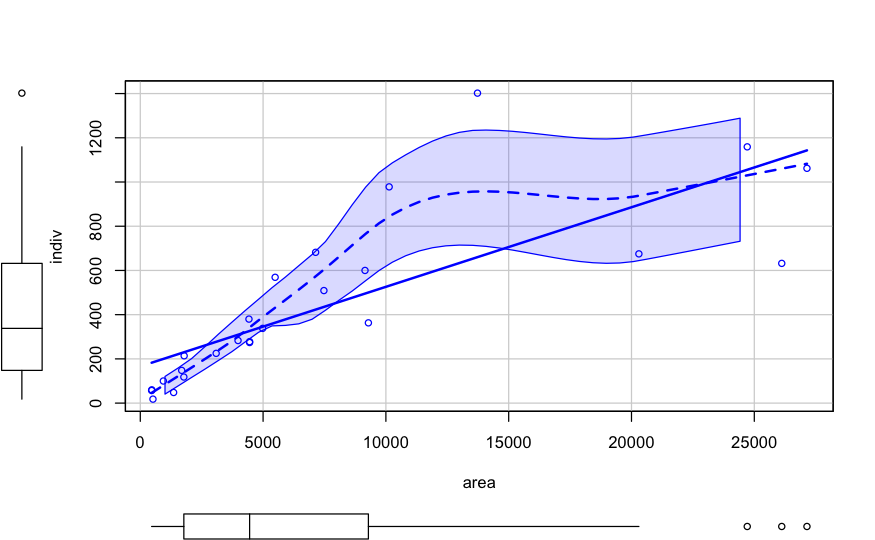

```r
scatterplot (indiv~area, data=peakquinn)
```

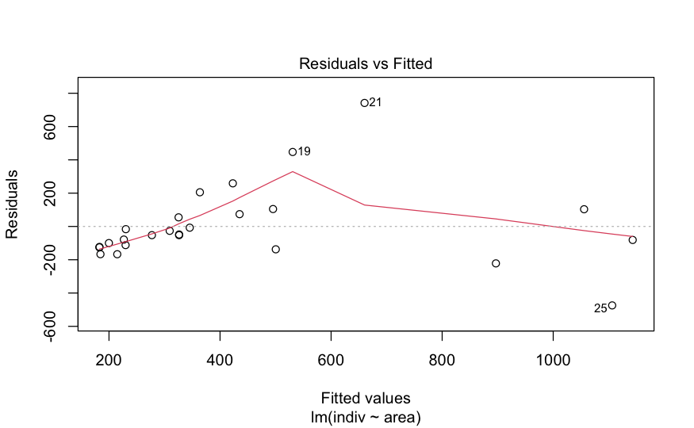

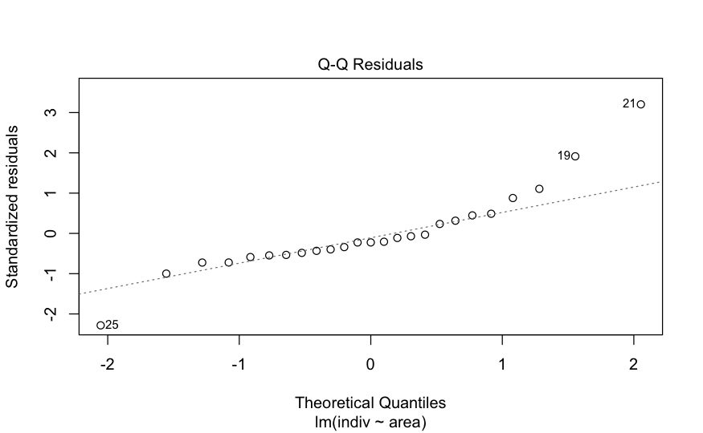

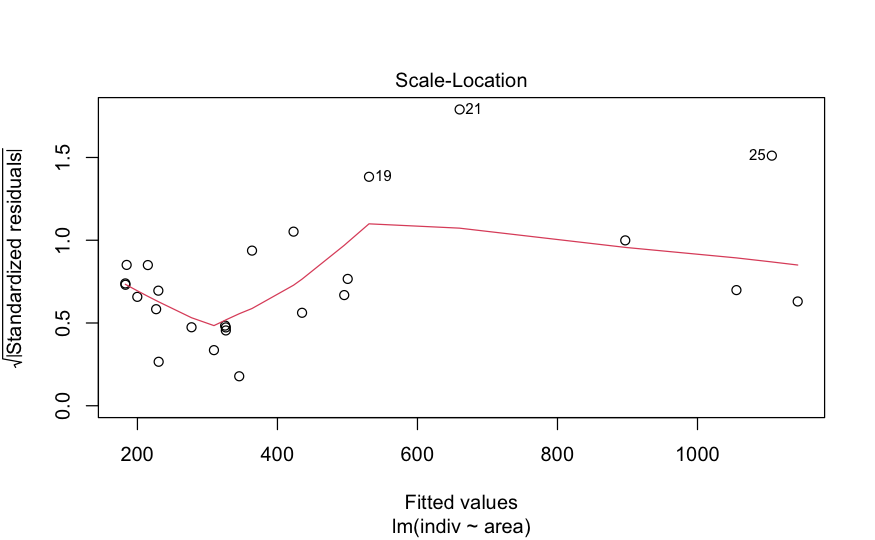

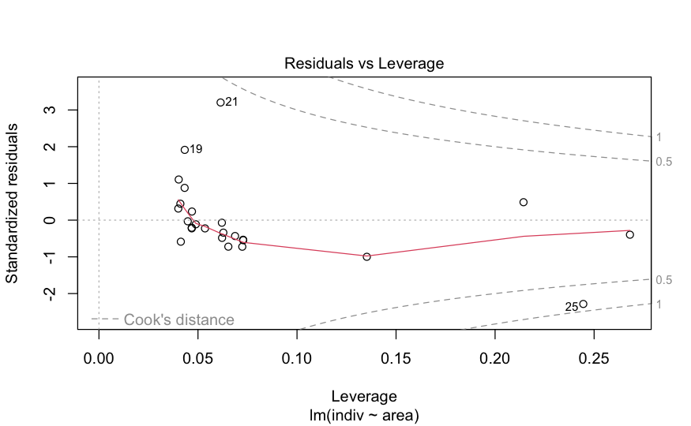

```r
pq2.lm<-lm(indiv~area,data=peakquinn)
plot(pq2.lm)
```

Scatterplot suggests non-linear relationship and the residual plot shows a pattern. Use log-transformed data

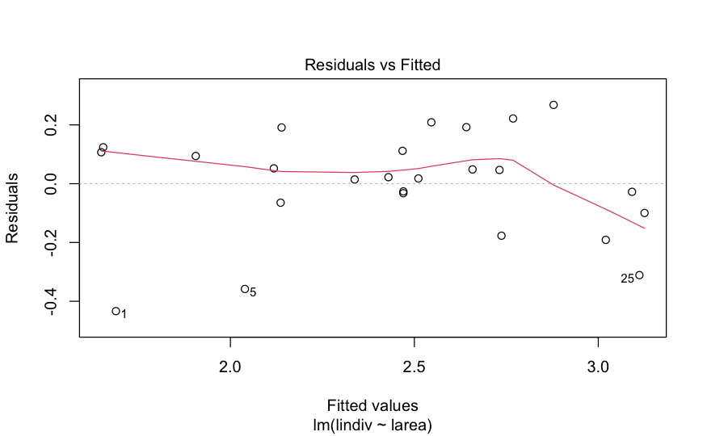

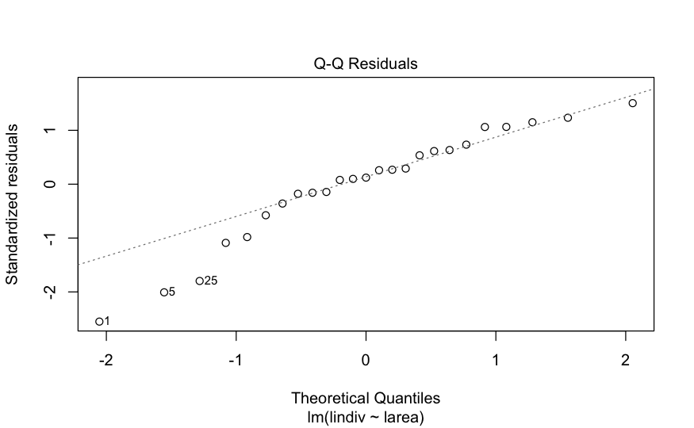

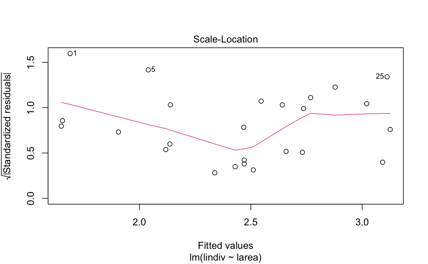

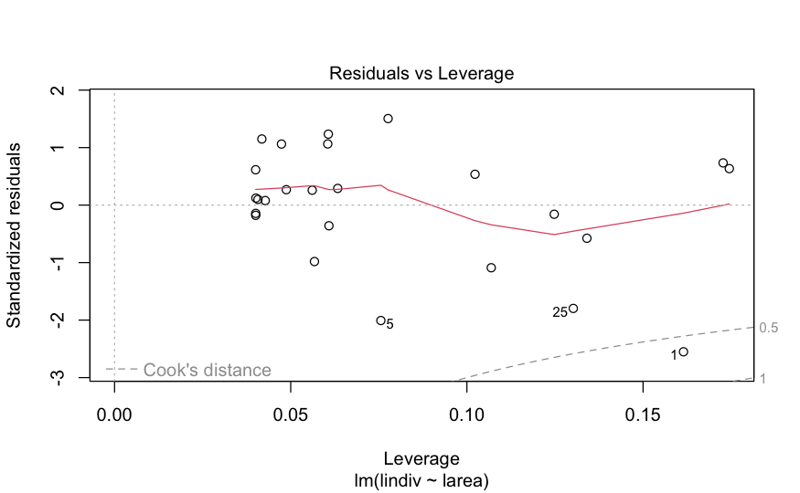

```r
pq3.lm<-lm(lindiv~larea, data=peakquinn)
plot(pq3.lm)
```

```r
augment(pq3.lm)
```

| lindiv | larea | .fitted | .resid | .hat | .sigma | .cooksd | .std.resid |
| --- | --- | --- | --- | --- | --- | --- | --- |
| 1.26 | 2.71 | 1.69 | -0.4335 | 0.1615 | 0.161 | 0.626553 | -2.5510 |
| 1.78 | 2.67 | 1.65 | 0.1239 | 0.1727 | 0.188 | 0.056245 | 0.7340 |
| 1.76 | 2.66 | 1.65 | 0.1069 | 0.1745 | 0.188 | 0.042502 | 0.6342 |
| 2.00 | 2.97 | 1.91 | 0.0942 | 0.1023 | 0.189 | 0.016366 | 0.5359 |
| 1.68 | 3.13 | 2.04 | -0.3582 | 0.0756 | 0.172 | 0.164749 | -2.0075 |
| 2.07 | 3.25 | 2.14 | -0.0646 | 0.0608 | 0.189 | 0.004183 | -0.3594 |
| 2.17 | 3.23 | 2.12 | 0.0521 | 0.0633 | 0.189 | 0.002846 | 0.2902 |
| 2.33 | 3.25 | 2.14 | 0.1913 | 0.0605 | 0.185 | 0.036423 | 1.0635 |
| 2.35 | 3.49 | 2.34 | 0.0144 | 0.0428 | 0.190 | 0.000140 | 0.0791 |
| 2.45 | 3.60 | 2.43 | 0.0222 | 0.0401 | 0.190 | 0.000311 | 0.1220 |

[output cut: 15 more lines]

```r
glance(pq3.lm)
```

| r.squared | adj.r.squared | sigma | statistic | p.value | df | logLik | AIC | BIC | deviance | df.residual | nobs |
| --- | --- | --- | --- | --- | --- | --- | --- | --- | --- | --- | --- |
| 0.859 | 0.852 | 0.186 | 140 | 3.01e-11 | 1 | 7.67 | -9.35 | -5.69 | 0.792 | 23 | 25 |

```r
tidy(pq3.lm, conf.int = TRUE)
```

| term | estimate | std.error | statistic | p.value | conf.low | conf.high |
| --- | --- | --- | --- | --- | --- | --- |
| (Intercept) | -0.576 | 0.2590 | -2.22 | 3.63e-02 | -1.112 | -0.0402 |
| larea | 0.835 | 0.0707 | 11.82 | 3.01e-11 | 0.689 | 0.9811 |

```r
#And if you want the traditional ANOVA table...
anova(pq3.lm)
```

```
Analysis of Variance Table

Response: lindiv
          Df Sum Sq Mean Sq F value Pr(>F)
larea      1   4.81    4.81     140  3e-11 ***
Residuals 23   0.79    0.03
---
Signif. codes:  0 ‘***’ 0.001 ‘**’ 0.01 ‘*’ 0.05 ‘.’ 0.1 ‘ ’ 1
```

## Nicer graphic

### Fig 6.13

First load script that produces standard graphics appearance (code hidden)

```r
p<-ggplot(peakquinn, aes(x=larea, y=lspecies))+
  geom_point(color=sc)+
  geom_smooth(method="lm", se=FALSE, color=lc)+
  theme_classic(base_size = 10)+
  theme(
    axis.text = element_text(colour = ac),
    axis.line = element_line(color = ac),
    axis.ticks = element_line(color = ac),
        )+
  xlab("Log area")+ylab("Log no. species")
#Add marginal box plots
p1<-ggMarginal(p,size=20, type="boxplot")
```

```
ℹ did you forget `aes(group = ...)`?Warning: Continuous x aesthetic
ℹ did you forget `aes(group = ...)`?
```

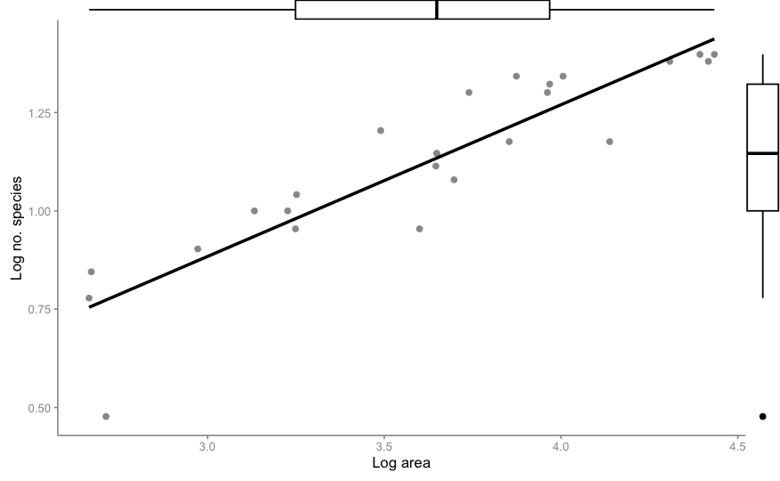

```r
p1
```

Residual plot

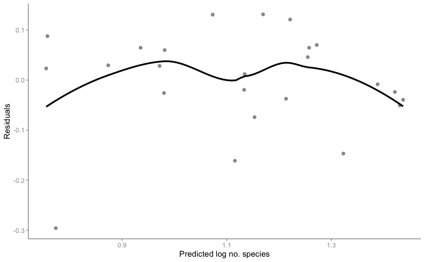

```r
p2<-ggplot(pq.lm, aes(x = pq.lm$fitted.values, y = pq.lm$residuals)) +
  geom_point(color=sc) +
  geom_smooth(se=FALSE, colour=lc)+
  theme_classic(base_size = 10)+
  theme(
    axis.text = element_text(colour = ac),
    axis.line = element_line(color = ac),
    axis.ticks = element_line(color = ac),
        )+labs(x = "Predicted log no. species", y = "Residuals",
       )
p2
```

#### Fig 6.14 - indiv vs area

```r
p3<-ggplot(peakquinn, aes(x=area, y=indiv))+
  geom_point(color = sc)+
  geom_smooth(se = FALSE, color = lc)+
  theme_classic(base_size = 10)+
  theme(
    axis.text = element_text(colour = ac),
    axis.line = element_line(color = ac),
    axis.ticks = element_line(color = ac),
        )+
  xlab("Area")+ylab("No. individuals")
#Add marginal box plots
p4<-ggMarginal(p3,size=20, type="boxplot")
```

```
ℹ did you forget `aes(group = ...)`?Warning: Continuous x aesthetic
ℹ did you forget `aes(group = ...)`?
```

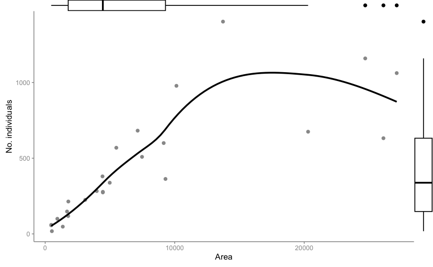

```r
p4
```

Residual plot

[figure not shown]

```r
p5<-ggplot(pq2.lm, aes(x = pq2.lm$fitted.values, y = pq2.lm$residuals)) +
  geom_point(color=sc) +
  theme_classic(base_size = 10)+
  theme(
    axis.text = element_text(colour = ac),
    axis.line = element_line(color = ac),
    axis.ticks = element_line(color = ac),
        )+labs(x = "Predicted log no. species", y = "Residuals",
       )
p5
```

[output not shown]

#### Fig 6.15

```r
p6<-ggplot(peakquinn, aes(x=larea, y=lindiv))+
  geom_point(color=sc)+
  geom_smooth(method="lm", color="black")+
  theme_classic(base_size = 10)+
  theme(
    axis.text = element_text(colour = ac),
    axis.line = element_line(color = ac),
    axis.ticks = element_line(color = ac),
        )+
  xlab("Log area")+ylab("Log no. indiv.")
#Add marginal box plots
p7<-ggMarginal(p6,size=20, type="boxplot")
```

```
ℹ did you forget `aes(group = ...)`?Warning: Continuous x aesthetic
ℹ did you forget `aes(group = ...)`?
```

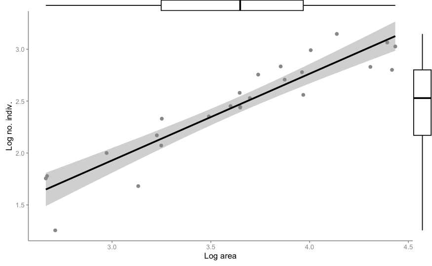

```r
p7
```

Residual plot

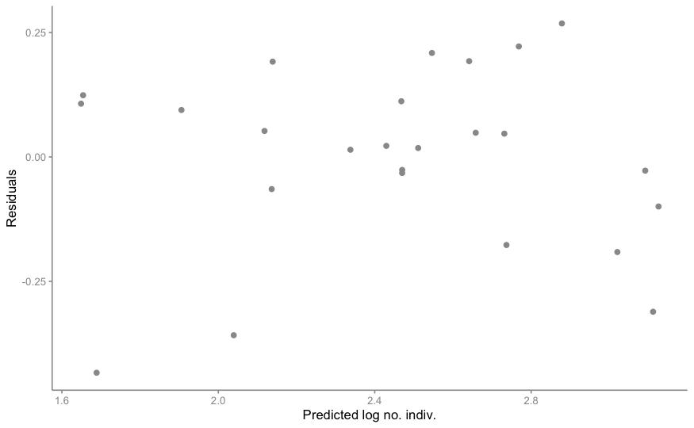

```r
p8<-ggplot(pq3.lm, aes(x = pq3.lm$fitted.values, y = pq3.lm$residuals)) +
  geom_point(color=sc) +
  theme_classic(base_size = 10)+
  theme(
    axis.text = element_text(colour = ac),
    axis.line = element_line(color = ac),
    axis.ticks = element_line(color = ac),
        )+labs(x = "Predicted log no. indiv.", y = "Residuals",
       )
p8
```